# Week 3 results

This week I learned

Wrangling:

- how to join data from two dataframes by using values of several columns as keys in matching
- example: math_por <- inner_join(math,por,by=join_us,suffix=c(“.math”, “.por”))
- how to create new columns by calculating factors from existing columns
- example: cols <- select(alc,one_of(c(“Dalc”,“Walc”))) *** alc[“alc_use”] <- rowMeans(cols)
- mutate dataframe: my_data <- mutate(my_data, prediction = probability > 0.5)

Analysis:

- Draw bar plots with ggplot + geom_bar
- create cross tabulated data summaries with group_by + summarise
- draw box plots with ggplot + geom_boxplot
- build logistic regression model with glm()
- apply pipe as %>%
- compute odds ratios & confidence intervals with coef() %>% exp
- compute confidence interval with confint() %>% exp
- make predictions using the model as probabilities <- predict(m, type = “response”)
- make confusion matrix with table as table(high_use = my_dataDOLhigh_use, prediction = my_dataDOLprediction)

## Useful links and resources

Original data used: https://archive.ics.uci.edu/ml/machine-learning-databases/00320/

### Links to some videos

Logit function, odds, logistic regression:

https://player.vimeo.com/video/202056054

Logistic regression model, example of odds:

https://player.vimeo.com/video/202056098

Model validation, k-fold cross validation:

https://player.vimeo.com/video/202056141

## Task

### Data wrangling part:

https://github.com/salopant/IODS-project/blob/master/data/create_alc.R

### Data analysis

#### Data described

Read first the data from the repository:

```r
alc <- read.csv("./data/alc_cons.csv")
str(alc)
```

```
## 'data.frame':    382 obs. of  35 variables:
##  $ school    : Factor w/ 2 levels "GP","MS": 1 1 1 1 1 1 1 1 1 1 ...
##  $ sex       : Factor w/ 2 levels "F","M": 1 1 1 1 1 2 2 1 2 2 ...
##  $ age       : int  18 17 15 15 16 16 16 17 15 15 ...
##  $ address   : Factor w/ 2 levels "R","U": 2 2 2 2 2 2 2 2 2 2 ...
##  $ famsize   : Factor w/ 2 levels "GT3","LE3": 1 1 2 1 1 2 2 1 2 1 ...
##  $ Pstatus   : Factor w/ 2 levels "A","T": 1 2 2 2 2 2 2 1 1 2 ...
##  $ Medu      : int  4 1 1 4 3 4 2 4 3 3 ...
##  $ Fedu      : int  4 1 1 2 3 3 2 4 2 4 ...
##  $ Mjob      : Factor w/ 5 levels "at_home","health",..: 1 1 1 2 3 4 3 3 4 3 ...
##  $ Fjob      : Factor w/ 5 levels "at_home","health",..: 5 3 3 4 3 3 3 5 3 3 ...
##  $ reason    : Factor w/ 4 levels "course","home",..: 1 1 3 2 2 4 2 2 2 2 ...
##  $ nursery   : Factor w/ 2 levels "no","yes": 2 1 2 2 2 2 2 2 2 2 ...
##  $ internet  : Factor w/ 2 levels "no","yes": 1 2 2 2 1 2 2 1 2 2 ...
##  $ guardian  : Factor w/ 3 levels "father","mother",..: 2 1 2 2 1 2 2 2 2 2 ...
```

[output cut: 21 more lines]

Target is to study what might explain the alcohol consumption level of the respondents, with logistic regression.

The explanations for the variables:

- `school` - student’s school (binary: ‘GP’ - Gabriel Pereira or ‘MS’ - Mousinho da Silveira) +`sex` - student’s sex (binary: ‘F’ - female or ‘M’ - male)
- `age` - student’s age (numeric: from 15 to 22)
- `address` - student’s home address type (binary: ‘U’ - urban or ‘R’ - rural)
- `famsize` - family size (binary: ‘LE3’ - less or equal to 3 or ‘GT3’ - greater than 3)
- `Pstatus` - parent’s cohabitation status (binary: ‘T’ - living together or ‘A’ - apart) + `Medu` - mother’s education (numeric: 0 - none, 1 - primary education (4th grade), 2 = 5th to 9th grade, 3 = secondary education or 4 = higher education)
- `Fedu` - father’s education (numeric: 0 - none, 1 - primary education (4th grade), 2 = 5th to 9th grade, 3 = secondary education or 4 = higher education)
- `Mjob` - mother’s job (nominal: ‘teacher’, ‘health’ care related, civil ‘services’ (e.g. administrative or police), ‘at_home’ or ‘other’)
- `Fjob` - father’s job (nominal: ‘teacher’, ‘health’ care related, civil ‘services’ (e.g. administrative or police), ‘at_home’ or ‘other’)
- `reason` - reason to choose this school (nominal: close to ‘home’, school ‘reputation’, ‘course’ preference or ‘other’)
- `guardian` - student’s guardian (nominal: ‘mother’, ‘father’ or ‘other’)
- `traveltime` - home to school travel time (numeric: 1 - <15 min., 2 - 15 to 30 min., 3 - 30 min. to 1 hour, or 4 - >1 hour)
- `studytime` - weekly study time (numeric: 1 - <2 hours, 2 - 2 to 5 hours, 3 - 5 to 10 hours, or 4 - >10 hours)
- `failures` - number of past class failures (numeric: n if 1<=n<3, else 4)
- `schoolsup` - extra educational support (binary: yes or no)
- `famsup` - family educational support (binary: yes or no)
- `paid` - extra paid classes within the course subject (Math or Portuguese) (binary: yes or no)
- `activities` - extra-curricular activities (binary: yes or no)
- `nursery` - attended nursery school (binary: yes or no)
- `higher` - wants to take higher education (binary: yes or no)
- `internet` - Internet access at home (binary: yes or no)
- `romantic` - with a romantic relationship (binary: yes or no)
- `famrel` - quality of family relationships (numeric: from 1 - very bad to 5 - excellent)
- `freetime` - free time after school (numeric: from 1 - very low to 5 - very high)
- `goout` - going out with friends (numeric: from 1 - very low to 5 - very high)
- `Dalc` - workday alcohol consumption (numeric: from 1 - very low to 5 - very high)
- `Walc` - weekend alcohol consumption (numeric: from 1 - very low to 5 - very high)
- `health` - current health status (numeric: from 1 - very bad to 5 - very good)
- `absences` - number of school absences (numeric: from 0 to 93)

These grades are related with the course subject, Math or Portuguese:

- `G1` - first period grade (numeric: from 0 to 20)
- `G2` - second period grade (numeric: from 0 to 20)
- `G3` - final grade (numeric: from 0 to 20, output target)

I choose to make research on features:

- `parent status` (together/apart)
- `number of failures` in courses
- `romantic relationship` (yes/no)
- `absense from school`

My hypotheses is that parents not living together increase the amount consumption as does a higher number of absences and failures in previous classes in school. A romantic relationship probably protects from extensive alcohol use.

```r
library(dplyr)
vars <- c("Pstatus", "failures","romantic","absences","alc_use","high_use")
my_data <- select(alc,one_of(vars))
head(my_data)
```

```
##   Pstatus failures romantic absences alc_use high_use
## 1       A        0       no        5     1.0    FALSE
## 2       T        0       no        3     1.0    FALSE
## 3       T        2       no        8     2.5     TRUE
## 4       T        0      yes        1     1.0    FALSE
## 5       T        0       no        2     1.5    FALSE
## 6       T        0       no        8     1.5    FALSE
```

Let us first have a look at the bar plots:

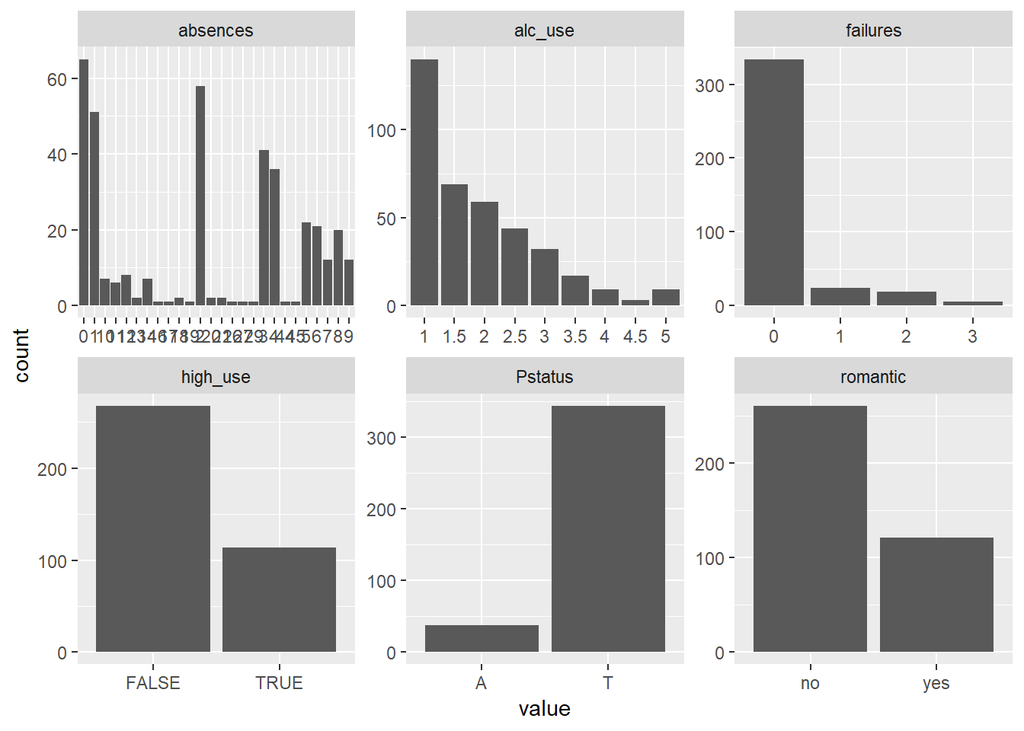

```r
library(tidyr); library(dplyr); library(ggplot2)

gather(my_data) %>% ggplot(aes(value)) + facet_wrap("key", scales = "free") + geom_bar()
```

Now, look at the cross tabulated data summaries to find out if the relations assumed as hypothesis could be true:

Parental status vs. alc use (mean)

```r
# produce summary statistics by group
my_data %>% group_by(Pstatus) %>% summarise(count = n(), mean_use= mean(alc_use))
```

```
## # A tibble: 2 x 3
##   Pstatus count mean_use
##   <fct>   <int>    <dbl>
## 1 A          38     1.84
## 2 T         344     1.89
```

The data does not show clear relationship.The number of parents not living together is realtively small but more important, the students having both parents at home consume a bit more on average.

Number of failures in classes:

```r
my_data %>% group_by(failures) %>% summarise(count = n(), mean_use= mean(alc_use))
```

```
## # A tibble: 4 x 3
##   failures count mean_use
##      <int> <int>    <dbl>
## 1        0   334     1.82
## 2        1    24     2.31
## 3        2    19     2.37
## 4        3     5     2.7
```

This data hints that there could be a positive correlation between these features i.e. higher number of failures implicates higher alchol consumption

Romatic relationships:

```r
my_data %>% group_by(romantic) %>% summarise(count = n(), mean_use= mean(alc_use))
```

```
## # A tibble: 2 x 3
##   romantic count mean_use
##   <fct>    <int>    <dbl>
## 1 no         261     1.87
## 2 yes        121     1.93
```

Looks like my hypothesis is wrong again, data rather suggests that student in a relationship consume more alcohol

Absence from school (Less/More than 6 times):

```r
my_data %>% group_by(absences>6) %>% summarise(count = n(), mean_use= mean(alc_use))
```

```
## # A tibble: 2 x 3
##   `absences > 6` count mean_use
##   <lgl>          <int>    <dbl>
## 1 FALSE            294     1.76
## 2 TRUE              88     2.32
```

Here the hypothesis might be true i.e. absence might increase the consumption a bit

Next have a look at some box plots

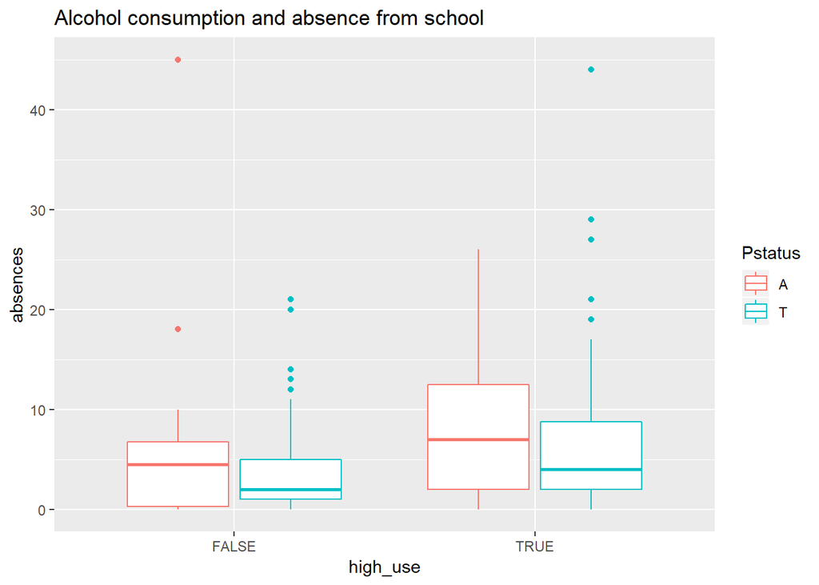

```r
# initialise a plot of high_use and absences
g2 <- ggplot(my_data, aes(x = high_use, y = absences, col = Pstatus))

# define the plot as a boxplot and draw it
g2 + geom_boxplot() + ylab("absences") + ggtitle("Alcohol consumption and absence from school")
```

Being absent from school is more common with students that use more alcohol in both groups of parental status

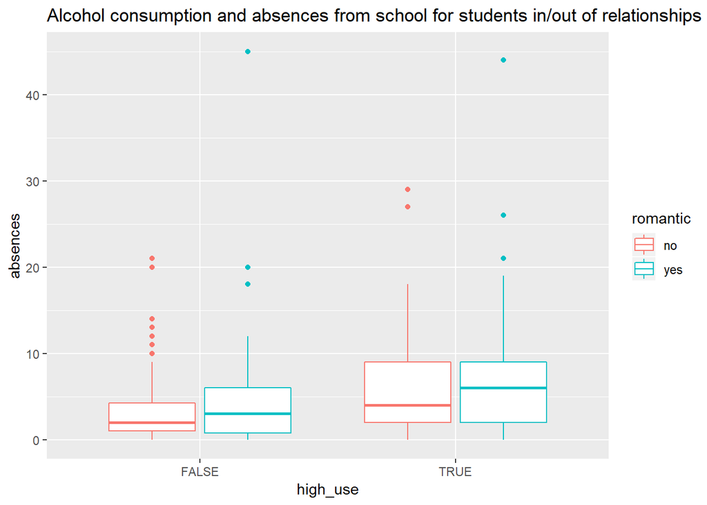

```r
# initialise a plot of high_use and absences
g2 <- ggplot(my_data, aes(x = high_use, y = absences, col = romantic))

# define the plot as a boxplot and draw it
g2 + geom_boxplot() + ylab("absences") + ggtitle("Alcohol consumption and absences from school for students in/out of relationships")
```

Being absent from school is more common with students that use more alcohol also in both groups of romantic relationships

#### Logistic regression

Build logistic regression model between alcohol usage (high use) and the four explanatory features (parental status, failures, absence, romantic relations)

```r
m <- glm(high_use ~ failures + absences + romantic + Pstatus, data = my_data, family = "binomial")

# print out a summary of the model
summary(m)
```

```
##
## Call:
## glm(formula = high_use ~ failures + absences + romantic + Pstatus,
##     family = "binomial", data = my_data)
##
## Deviance Residuals:
##     Min       1Q   Median       3Q      Max
## -2.1965  -0.7853  -0.7250   1.1982   1.8858
##
## Coefficients:
##             Estimate Std. Error z value Pr(>|z|)
## (Intercept) -1.37116    0.40910  -3.352 0.000803 ***
## failures     0.50157    0.18592   2.698 0.006982 **
## absences     0.08871    0.02307   3.845 0.000121 ***
## romanticyes -0.30245    0.25639  -1.180 0.238149
## PstatusT     0.08052    0.39230   0.205 0.837369
## ---
## Signif. codes:  0 '***' 0.001 '**' 0.01 '*' 0.05 '.' 0.1 ' ' 1
##
## (Dispersion parameter for binomial family taken to be 1)
##
##     Null deviance: 465.68  on 381  degrees of freedom
## Residual deviance: 438.66  on 377  degrees of freedom
## AIC: 448.66
##
## Number of Fisher Scoring iterations: 4
```

The summary of the parameters show that both course failures and absence from school indeed correlate positively the alcohol consumption in risk level 5%. Romantic relationships however does not protect from alcohol consumption and neither does a static relationship of the parents.

Make a new model with only the two significant variables:

```r
m <- glm(high_use ~ failures + absences, data = my_data, family = "binomial")

# print out a summary of the model
summary(m)
```

```
##
## Call:
## glm(formula = high_use ~ failures + absences, family = "binomial",
##     data = my_data)
##
## Deviance Residuals:
##     Min       1Q   Median       3Q      Max
## -2.2680  -0.8019  -0.6967   1.2522   1.7906
##
## Coefficients:
##             Estimate Std. Error z value Pr(>|z|)
## (Intercept) -1.37829    0.16479  -8.364  < 2e-16 ***
## failures     0.49972    0.18456   2.708 0.006776 **
## absences     0.08602    0.02287   3.762 0.000169 ***
## ---
## Signif. codes:  0 '***' 0.001 '**' 0.01 '*' 0.05 '.' 0.1 ' ' 1
##
## (Dispersion parameter for binomial family taken to be 1)
##
##     Null deviance: 465.68  on 381  degrees of freedom
## Residual deviance: 440.14  on 379  degrees of freedom
## AIC: 446.14
##
## Number of Fisher Scoring iterations: 4
```

```r
# compute odds ratios (OR)
OR <- coef(m) %>% exp

# compute confidence intervals (CI)
CI <- confint(m) %>% exp
# print out the odds ratios with their confidence intervals
cbind(OR, CI)
```

```
##                   OR     2.5 %    97.5 %
## (Intercept) 0.252010 0.1806814 0.3450734
## failures    1.648255 1.1488991 2.3830880
## absences    1.089826 1.0443334 1.1423489
```

Make a prediction:

```r
# predict() the probability of high_use
probabilities <- predict(m, type = "response")

# add the predicted probabilities to 'my_data'
my_data <- mutate(my_data, probability = probabilities)

# use the probabilities to make a prediction of high_use
my_data <- mutate(my_data, prediction = probability > 0.5)

# see the last ten original classes, predicted probabilities, and class predictions
select(my_data, failures, absences, high_use, probability, prediction) %>% tail(10)
```

```
##     failures absences high_use probability prediction
## 373        1        0    FALSE   0.2934743      FALSE
## 374        1        7     TRUE   0.4313255      FALSE
## 375        0        1    FALSE   0.2154691      FALSE
## 376        0        6    FALSE   0.2968841      FALSE
## 377        1        2    FALSE   0.3303652      FALSE
## 378        0        2    FALSE   0.2303651      FALSE
## 379        2        2    FALSE   0.4484793      FALSE
## 380        0        3    FALSE   0.2459680      FALSE
## 381        0        4     TRUE   0.2622677      FALSE
## 382        0        2     TRUE   0.2303651      FALSE
```

```r
# tabulate the target variable versus the predictions
table(high_use = my_data$high_use, prediction = my_data$prediction)
```

```
##         prediction
## high_use FALSE TRUE
##    FALSE   258   10
##    TRUE     99   15
```

This confusion matrix above shows that the model is not very good in predicting high level use of alcohol. Only 15 cases of 114 are correctly predicted

Same thing graphically:

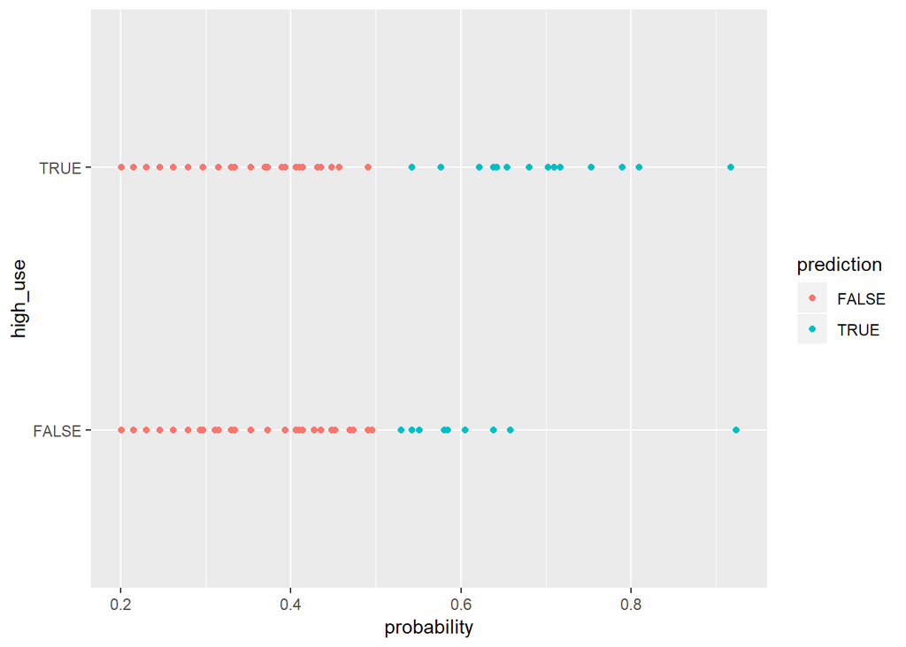

```r
# initialize a plot of 'high_use' versus 'probability' in 'alc'
g <- ggplot(my_data, aes(x = probability, y = high_use))

# define the geom as points and draw the plot
g + geom_point(aes(col = prediction))
```

```r
# tabulate the target variable versus the predictions
table(high_use = my_data$high_use, prediction = my_data$prediction)%>% prop.table()%>%addmargins()
```

```
##         prediction
## high_use      FALSE       TRUE        Sum
##    FALSE 0.67539267 0.02617801 0.70157068
##    TRUE  0.25916230 0.03926702 0.29842932
##    Sum   0.93455497 0.06544503 1.00000000
```